# Telco Customer Churn

*Importing Packages*

At first, we will import all the libraries that would be used in the project.

```r
library(moments)
library(dplyr)
library(rpart)
library(rpart.plot)
library(randomForest)
library(caret)
library(ggplot2)
```

*Importing Dataset*

Now, we will import the dataset into our working file.

```r
churnData <- read.csv('https://raw.githubusercontent.com/Hannah-Susan-Mathew/Datasets/main/Telco-Customer-Churn.csv', stringsAsFactors = TRUE)
```

*Understanding the Dataset*

In order to understand the data we use `summarize()` and `str()` functions.

```r
churnData
```

| customerID | gender | SeniorCitizen | Partner | Dependents | tenure | PhoneService | MultipleLines | InternetService | OnlineSecurity | OnlineBackup | DeviceProtection | TechSupport | StreamingTV | StreamingMovies | Contract | PaperlessBilling | PaymentMethod | MonthlyCharges | TotalCharges | Churn |
| --- | --- | --- | --- | --- | --- | --- | --- | --- | --- | --- | --- | --- | --- | --- | --- | --- | --- | --- | --- | --- |
| 7590-VHVEG | Female | 0 | Yes | No | 1 | No | No phone service | DSL | No | Yes | No | No | No | No | Month-to-month | Yes | Electronic check | 29.85 | 29.85 | No |
| 5575-GNVDE | Male | 0 | No | No | 34 | Yes | No | DSL | Yes | No | Yes | No | No | No | One year | No | Mailed check | 56.95 | 1889.50 | No |
| 3668-QPYBK | Male | 0 | No | No | 2 | Yes | No | DSL | Yes | Yes | No | No | No | No | Month-to-month | Yes | Mailed check | 53.85 | 108.15 | Yes |
| 7795-CFOCW | Male | 0 | No | No | 45 | No | No phone service | DSL | Yes | No | Yes | Yes | No | No | One year | No | Bank transfer (automatic) | 42.30 | 1840.75 | No |
| 9237-HQITU | Female | 0 | No | No | 2 | Yes | No | Fiber optic | No | No | No | No | No | No | Month-to-month | Yes | Electronic check | 70.70 | 151.65 | Yes |
| 9305-CDSKC | Female | 0 | No | No | 8 | Yes | Yes | Fiber optic | No | No | Yes | No | Yes | Yes | Month-to-month | Yes | Electronic check | 99.65 | 820.50 | Yes |
| 1452-KIOVK | Male | 0 | No | Yes | 22 | Yes | Yes | Fiber optic | No | Yes | No | No | Yes | No | Month-to-month | Yes | Credit card (automatic) | 89.10 | 1949.40 | No |
| 6713-OKOMC | Female | 0 | No | No | 10 | No | No phone service | DSL | Yes | No | No | No | No | No | Month-to-month | No | Mailed check | 29.75 | 301.90 | No |
| 7892-POOKP | Female | 0 | Yes | No | 28 | Yes | Yes | Fiber optic | No | No | Yes | Yes | Yes | Yes | Month-to-month | Yes | Electronic check | 104.80 | 3046.05 | Yes |
| 6388-TABGU | Male | 0 | No | Yes | 62 | Yes | No | DSL | Yes | Yes | No | No | No | No | One year | No | Bank transfer (automatic) | 56.15 | 3487.95 | No |

[output cut: 990 more lines]

| customerID <fctr> | gender <fctr> | SeniorCitizen <int> | Partner <fctr> | Dependents <fctr> | tenure <int> | PhoneService <fctr> | MultipleLines <fctr> |  |
| --- | --- | --- | --- | --- | --- | --- | --- | --- |
| 7590-VHVEG | Female | 0 | Yes | No | 1 | No | No phone service |  |
| 5575-GNVDE | Male | 0 | No | No | 34 | Yes | No |  |
| 3668-QPYBK | Male | 0 | No | No | 2 | Yes | No |  |
| 7795-CFOCW | Male | 0 | No | No | 45 | No | No phone service |  |
| 9237-HQITU | Female | 0 | No | No | 2 | Yes | No |  |
| 9305-CDSKC | Female | 0 | No | No | 8 | Yes | Yes |  |
| 1452-KIOVK | Male | 0 | No | Yes | 22 | Yes | Yes |  |
| 6713-OKOMC | Female | 0 | No | No | 10 | No | No phone service |  |
| 7892-POOKP | Female | 0 | Yes | No | 28 | Yes | Yes |  |
| 6388-TABGU | Male | 0 | No | Yes | 62 | Yes | No |  |

1-10 of 7,043 rows | 1-8 of 21 columns

```r
str(churnData)
```

```
'data.frame':   7043 obs. of  21 variables:
 $ customerID      : Factor w/ 7043 levels "0002-ORFBO","0003-MKNFE",..: 5376 3963 2565 5536 6512 6552 1003 4771 5605 4535 ...
 $ gender          : Factor w/ 2 levels "Female","Male": 1 2 2 2 1 1 2 1 1 2 ...
 $ SeniorCitizen   : int  0 0 0 0 0 0 0 0 0 0 ...
 $ Partner         : Factor w/ 2 levels "No","Yes": 2 1 1 1 1 1 1 1 2 1 ...
 $ Dependents      : Factor w/ 2 levels "No","Yes": 1 1 1 1 1 1 2 1 1 2 ...
 $ tenure          : int  1 34 2 45 2 8 22 10 28 62 ...
 $ PhoneService    : Factor w/ 2 levels "No","Yes": 1 2 2 1 2 2 2 1 2 2 ...
 $ MultipleLines   : Factor w/ 3 levels "No","No phone service",..: 2 1 1 2 1 3 3 2 3 1 ...
 $ InternetService : Factor w/ 3 levels "DSL","Fiber optic",..: 1 1 1 1 2 2 2 1 2 1 ...
 $ OnlineSecurity  : Factor w/ 3 levels "No","No internet service",..: 1 3 3 3 1 1 1 3 1 3 ...
 $ OnlineBackup    : Factor w/ 3 levels "No","No internet service",..: 3 1 3 1 1 1 3 1 1 3 ...
 $ DeviceProtection: Factor w/ 3 levels "No","No internet service",..: 1 3 1 3 1 3 1 1 3 1 ...
 $ TechSupport     : Factor w/ 3 levels "No","No internet service",..: 1 1 1 3 1 1 1 1 3 1 ...
 $ StreamingTV     : Factor w/ 3 levels "No","No internet service",..: 1 1 1 1 1 3 3 1 3 1 ...
 $ StreamingMovies : Factor w/ 3 levels "No","No internet service",..: 1 1 1 1 1 3 1 1 3 1 ...
 $ Contract        : Factor w/ 3 levels "Month-to-month",..: 1 2 1 2 1 1 1 1 1 2 ...
 $ PaperlessBilling: Factor w/ 2 levels "No","Yes": 2 1 2 1 2 2 2 1 2 1 ...
 $ PaymentMethod   : Factor w/ 4 levels "Bank transfer (automatic)",..: 3 4 4 1 3 3 2 4 3 1 ...
 $ MonthlyCharges  : num  29.9 57 53.9 42.3 70.7 ...
 $ TotalCharges    : num  29.9 1889.5 108.2 1840.8 151.7 ...
 $ Churn           : Factor w/ 2 levels "No","Yes": 1 1 2 1 2 2 1 1 2 1 ...
```

We see that our dataset has 21 columns and 7043 rows. Also, all the `string` columns are now taken as factors. We also note that the `SeniorCitizen` column’s data type is given as `int`, which actually is not true. Rather, its data type is supposed to be factors. We will consider this during the pre-processing step.

```r
summary(churnData)
```

```
      customerID      gender     SeniorCitizen    Partner    Dependents     tenure
 0002-ORFBO:   1   Female:3488   Min.   :0.0000   No :3641   No :4933   Min.   : 0.00
 0003-MKNFE:   1   Male  :3555   1st Qu.:0.0000   Yes:3402   Yes:2110   1st Qu.: 9.00
 0004-TLHLJ:   1                 Median :0.0000                         Median :29.00
 0011-IGKFF:   1                 Mean   :0.1621                         Mean   :32.37
 0013-EXCHZ:   1                 3rd Qu.:0.0000                         3rd Qu.:55.00
 0013-MHZWF:   1                 Max.   :1.0000                         Max.   :72.00
 (Other)   :7037
 PhoneService          MultipleLines     InternetService             OnlineSecurity
 No : 682     No              :3390   DSL        :2421   No                 :3498
 Yes:6361     No phone service: 682   Fiber optic:3096   No internet service:1526
              Yes             :2971   No         :1526   Yes                :2019




              OnlineBackup             DeviceProtection              TechSupport
 No                 :3088   No                 :3095    No                 :3473
 No internet service:1526   No internet service:1526    No internet service:1526
 Yes                :2429   Yes                :2422    Yes                :2044




              StreamingTV              StreamingMovies           Contract    PaperlessBilling
 No                 :2810   No                 :2785   Month-to-month:3875   No :2872
 No internet service:1526   No internet service:1526   One year      :1473   Yes:4171
 Yes                :2707   Yes                :2732   Two year      :1695




                   PaymentMethod  MonthlyCharges    TotalCharges    Churn
 Bank transfer (automatic):1544   Min.   : 18.25   Min.   :  18.8   No :5174
 Credit card (automatic)  :1522   1st Qu.: 35.50   1st Qu.: 401.4   Yes:1869
 Electronic check         :2365   Median : 70.35   Median :1397.5
 Mailed check             :1612   Mean   : 64.76   Mean   :2283.3
                                  3rd Qu.: 89.85   3rd Qu.:3794.7
                                  Max.   :118.75   Max.   :8684.8
                                                   NA's   :11
```

In the summary, it is clear that all but `TotalCharges` columns has no `NA` values. We will work with the null values of the column in the preprocessing step. *Data Preprocessing*

It is mandatory that we preprocess the dataset before working on it. From the `summary()` function we see that `TotalCharges` has *11 NA* values. Thus we need to impute it. We see that the maximum value that `TotalCharges` in each row can take is the product of `tenure` and `MonthlyCharges`. Hence the missing values are replaced with `tenure * MonthlyCharges` for each row.

```r
sum(is.na(churnData))
```

```
[1] 11
```

```r
sum(is.na(churnData$TotalCharges))
```

```
[1] 11
```

```r
churnData$TotalCharges <- ifelse(is.na(churnData$TotalCharges), churnData$MonthlyCharges*churnData$tenure, churnData$TotalCharges)
```

```r
sum(is.na(churnData))
```

```
[1] 0
```

Finally, our data is clean of missing values.

In the summary, we see that the minimum value of tenure column is 0. But, analysing customers who have been for 0 months is not effective. Hene we remove the rows which have tenure as 0.

```r
churnData <- churnData[!(churnData$tenure == 0),]
summary(churnData)
```

```
      customerID      gender     SeniorCitizen    Partner    Dependents     tenure
 0002-ORFBO:   1   Female:3483   Min.   :0.0000   No :3639   No :4933   Min.   : 1.00
 0003-MKNFE:   1   Male  :3549   1st Qu.:0.0000   Yes:3393   Yes:2099   1st Qu.: 9.00
 0004-TLHLJ:   1                 Median :0.0000                         Median :29.00
 0011-IGKFF:   1                 Mean   :0.1624                         Mean   :32.42
 0013-EXCHZ:   1                 3rd Qu.:0.0000                         3rd Qu.:55.00
 0013-MHZWF:   1                 Max.   :1.0000                         Max.   :72.00
 (Other)   :7026
 PhoneService          MultipleLines     InternetService             OnlineSecurity
 No : 680     No              :3385   DSL        :2416   No                 :3497
 Yes:6352     No phone service: 680   Fiber optic:3096   No internet service:1520
              Yes             :2967   No         :1520   Yes                :2015




              OnlineBackup             DeviceProtection              TechSupport
 No                 :3087   No                 :3094    No                 :3472
 No internet service:1520   No internet service:1520    No internet service:1520
 Yes                :2425   Yes                :2418    Yes                :2040




              StreamingTV              StreamingMovies           Contract    PaperlessBilling
 No                 :2809   No                 :2781   Month-to-month:3875   No :2864
 No internet service:1520   No internet service:1520   One year      :1472   Yes:4168
 Yes                :2703   Yes                :2731   Two year      :1685




                   PaymentMethod  MonthlyCharges    TotalCharges    Churn
 Bank transfer (automatic):1542   Min.   : 18.25   Min.   :  18.8   No :5163
 Credit card (automatic)  :1521   1st Qu.: 35.59   1st Qu.: 401.4   Yes:1869
 Electronic check         :2365   Median : 70.35   Median :1397.5
 Mailed check             :1604   Mean   : 64.80   Mean   :2283.3
                                  3rd Qu.: 89.86   3rd Qu.:3794.7
                                  Max.   :118.75   Max.   :8684.8
```

```r
# Function to find Mode

getmode <- function(v) {
   uniqv <- unique(v)
   uniqv[which.max(tabulate(match(v, uniqv)))]
}

getmode(churnData$tenure)
```

```
[1] 1
```

```r
getmode(churnData$MonthlyCharges)
```

```
[1] 20.05
```

```r
getmode(churnData$TotalCharges)
```

```
[1] 20.2
```

```r
skewness(churnData$tenure)
```

```
[1] 0.2376801
```

```r
skewness(churnData$MonthlyCharges)
```

```
[1] -0.2220555
```

```r
skewness(churnData$TotalCharges)
```

```
[1] 0.9614374
```

```r
kurtosis(churnData$tenure)
```

```
[1] 1.612311
```

```r
kurtosis(churnData$MonthlyCharges)
```

```
[1] 1.743883
```

```r
kurtosis(churnData$TotalCharges)
```

```
[1] 2.767513
```

Now it is clear that customerID is not of much use. Hence, it is discarded.

```r
churnData <- churnData[,-1]
```

Now our dataset has 20 columns.

```r
churnData
```

|  | gender | SeniorCitizen | Partner | Dependents | tenure | PhoneService | MultipleLines | InternetService | OnlineSecurity | OnlineBackup | DeviceProtection | TechSupport | StreamingTV | StreamingMovies | Contract | PaperlessBilling | PaymentMethod | MonthlyCharges | TotalCharges | Churn |
| --- | --- | --- | --- | --- | --- | --- | --- | --- | --- | --- | --- | --- | --- | --- | --- | --- | --- | --- | --- | --- |
| 1 | Female | 0 | Yes | No | 1 | No | No phone service | DSL | No | Yes | No | No | No | No | Month-to-month | Yes | Electronic check | 29.85 | 29.85 | No |
| 2 | Male | 0 | No | No | 34 | Yes | No | DSL | Yes | No | Yes | No | No | No | One year | No | Mailed check | 56.95 | 1889.50 | No |
| 3 | Male | 0 | No | No | 2 | Yes | No | DSL | Yes | Yes | No | No | No | No | Month-to-month | Yes | Mailed check | 53.85 | 108.15 | Yes |
| 4 | Male | 0 | No | No | 45 | No | No phone service | DSL | Yes | No | Yes | Yes | No | No | One year | No | Bank transfer (automatic) | 42.30 | 1840.75 | No |
| 5 | Female | 0 | No | No | 2 | Yes | No | Fiber optic | No | No | No | No | No | No | Month-to-month | Yes | Electronic check | 70.70 | 151.65 | Yes |
| 6 | Female | 0 | No | No | 8 | Yes | Yes | Fiber optic | No | No | Yes | No | Yes | Yes | Month-to-month | Yes | Electronic check | 99.65 | 820.50 | Yes |
| 7 | Male | 0 | No | Yes | 22 | Yes | Yes | Fiber optic | No | Yes | No | No | Yes | No | Month-to-month | Yes | Credit card (automatic) | 89.10 | 1949.40 | No |
| 8 | Female | 0 | No | No | 10 | No | No phone service | DSL | Yes | No | No | No | No | No | Month-to-month | No | Mailed check | 29.75 | 301.90 | No |
| 9 | Female | 0 | Yes | No | 28 | Yes | Yes | Fiber optic | No | No | Yes | Yes | Yes | Yes | Month-to-month | Yes | Electronic check | 104.80 | 3046.05 | Yes |
| 10 | Male | 0 | No | Yes | 62 | Yes | No | DSL | Yes | Yes | No | No | No | No | One year | No | Bank transfer (automatic) | 56.15 | 3487.95 | No |

[output cut: 990 more lines]

|  | gender <fctr> | SeniorCitizen <int> | Partner <fctr> | Dependents <fctr> | tenure <int> | PhoneService <fctr> | MultipleLines <fctr> | InternetService <fctr> |  |
| --- | --- | --- | --- | --- | --- | --- | --- | --- | --- |
| 1 | Female | 0 | Yes | No | 1 | No | No phone service | DSL |  |
| 2 | Male | 0 | No | No | 34 | Yes | No | DSL |  |
| 3 | Male | 0 | No | No | 2 | Yes | No | DSL |  |
| 4 | Male | 0 | No | No | 45 | No | No phone service | DSL |  |
| 5 | Female | 0 | No | No | 2 | Yes | No | Fiber optic |  |
| 6 | Female | 0 | No | No | 8 | Yes | Yes | Fiber optic |  |
| 7 | Male | 0 | No | Yes | 22 | Yes | Yes | Fiber optic |  |
| 8 | Female | 0 | No | No | 10 | No | No phone service | DSL |  |
| 9 | Female | 0 | Yes | No | 28 | Yes | Yes | Fiber optic |  |
| 10 | Male | 0 | No | Yes | 62 | Yes | No | DSL |  |

1-10 of 7,032 rows | 1-9 of 20 columns

As noticed in `str(churnData)`, the `SeniorCitizen` column is of type `int`. But actually, it has categorical values. Hence, it is converted to factor levels.

```r
churnData$SeniorCitizen <- factor(churnData$SeniorCitizen)
```

```r
str(churnData$SeniorCitizen)
```

```
 Factor w/ 2 levels "0","1": 1 1 1 1 1 1 1 1 1 1 ...
```

We have three numerical columns and their range differences from each other. Hence, we scale the numerical columns using `Standard Scaling`.

```r
churnData$MonthlyCharges <- scale(churnData$MonthlyCharges)
churnData$TotalCharges <- scale(churnData$TotalCharges)
churnData$tenure <- scale(churnData$tenure)
```

```r
summary(churnData)
```

```
    gender     SeniorCitizen Partner    Dependents      tenure.V1       PhoneService
 Female:3483   0:5890        No :3639   No :4933   Min.   :-1.2801570   No : 680
 Male  :3549   1:1142        Yes:3393   Yes:2099   1st Qu.:-0.9542285   Yes:6352
                                                   Median :-0.1394072
                                                   Mean   : 0.0000000
                                                   3rd Qu.: 0.9198605
                                                   Max.   : 1.6124585
          MultipleLines     InternetService             OnlineSecurity              OnlineBackup
 No              :3385   DSL        :2416   No                 :3497   No                 :3087
 No phone service: 680   Fiber optic:3096   No internet service:1520   No internet service:1520
 Yes             :2967   No         :1520   Yes                :2015   Yes                :2425



            DeviceProtection              TechSupport                StreamingTV
 No                 :3094    No                 :3472   No                 :2809
 No internet service:1520    No internet service:1520   No internet service:1520
 Yes                :2418    Yes                :2040   Yes                :2703



            StreamingMovies           Contract    PaperlessBilling
 No                 :2781   Month-to-month:3875   No :2864
 No internet service:1520   One year      :1472   Yes:4168
 Yes                :2731   Two year      :1685



                   PaymentMethod   MonthlyCharges.V1     TotalCharges.V1    Churn
 Bank transfer (automatic):1542   Min.   :-1.5471731   Min.   :-0.9989982   No :5163
 Credit card (automatic)  :1521   1st Qu.:-0.9709078   1st Qu.:-0.8301898   Yes:1869
 Electronic check         :2365   Median : 0.1845309   Median :-0.3907873
 Mailed check             :1604   Mean   : 0.0000000   Mean   : 0.0000000
                                  3rd Qu.: 0.8330889   3rd Qu.: 0.6667797
                                  Max.   : 1.7932540   Max.   : 2.8240605
```

```r
set.seed(2020)
```

*Train-Test Splitting the Dataset* Now we will split the new dataset into train set and test set. The train-test splitting ratio is taken as `65:35`.

```r
Index <- sample(nrow(churnData),0.65*nrow(churnData))
Trainchurn <- churnData[Index,]
Testchurn <- churnData[-Index,]
```

*Modelling*

Now we will move to modelling. Since, the target column-`Churn`-has binary values, we will use Logistic Regresssion, Decision Tree and Random Forest. **1. Decision Tree** The splitting criterion used is *Gini Index*.

```r
Tree <- rpart(Churn~., Trainchurn, method = 'class', parms = list(split = 'gini'))
summary(Tree)
```

```
Call:
rpart(formula = Churn ~ ., data = Trainchurn, method = "class",
    parms = list(split = "gini"))
  n= 4570

          CP nsplit rel error    xerror       xstd
1 0.06826314      0 1.0000000 1.0000000 0.02463626
2 0.01000000      3 0.7952106 0.8340215 0.02316239

Variable importance
        Contract           tenure     TotalCharges      TechSupport   OnlineSecurity
              23               16               11               11                9
DeviceProtection   MonthlyCharges  InternetService     OnlineBackup    MultipleLines
               9                8                7                3                1
         Partner
               1

Node number 1: 4570 observations,    complexity param=0.06826314
  predicted class=No   expected loss=0.2649891  P(node) =1
    class counts:  3359  1211
   probabilities: 0.735 0.265
  left son=2 (2029 obs) right son=3 (2541 obs)
  Primary splits:
      Contract        splits as  RLL, improve=280.3428, (0 missing)
      TechSupport     splits as  RLL, improve=200.7930, (0 missing)
      OnlineSecurity  splits as  RLL, improve=197.0965, (0 missing)
      tenure          < -0.6079294 to the right, improve=176.0622, (0 missing)
      InternetService splits as  LRL, improve=172.4137, (0 missing)
  Surrogate splits:
      tenure           < 0.1254097  to the right, agree=0.791, adj=0.529, (0 split)
      TechSupport      splits as  RLL, agree=0.715, adj=0.359, (0 split)
      TotalCharges     < 0.31986    to the right, agree=0.700, adj=0.324, (0 split)
      OnlineSecurity   splits as  RLL, agree=0.692, adj=0.307, (0 split)
      DeviceProtection splits as  RLL, agree=0.688, adj=0.297, (0 split)

Node number 2: 2029 observations
  predicted class=No   expected loss=0.06899951  P(node) =0.4439825
    class counts:  1889   140
   probabilities: 0.931 0.069

```

[output cut: 35 more lines]

```
      TotalCharges   < -0.3069345 to the right, agree=0.970, adj=0.939, (0 split)
      MonthlyCharges < 0.6124712  to the right, agree=0.656, adj=0.298, (0 split)
      MultipleLines  splits as  R-L, agree=0.634, adj=0.254, (0 split)
      OnlineBackup   splits as  R-L, agree=0.620, adj=0.226, (0 split)
      Partner        splits as  RL, agree=0.607, adj=0.200, (0 split)

Node number 14: 694 observations
  predicted class=No   expected loss=0.4020173  P(node) =0.15186
    class counts:   415   279
   probabilities: 0.598 0.402

Node number 15: 720 observations
  predicted class=Yes  expected loss=0.3277778  P(node) =0.1575492
    class counts:   236   484
   probabilities: 0.328 0.672
```

Now we will evaluate the decision tree model. In order to evaluate the model, we will use a confusion matrix.

```r
pred_Tree <- predict(Tree, Testchurn, type='class')

Tree_cm <- confusionMatrix(pred_Tree, Testchurn$Churn, mode = "everything")
Tree_cm
```

```
Confusion Matrix and Statistics

          Reference
Prediction   No  Yes
       No  1684  385
       Yes  120  273

               Accuracy : 0.7949
                 95% CI : (0.7784, 0.8107)
    No Information Rate : 0.7327
    P-Value [Acc > NIR] : 4.785e-13

                  Kappa : 0.3995

 Mcnemar's Test P-Value : < 2.2e-16

            Sensitivity : 0.9335
            Specificity : 0.4149
         Pos Pred Value : 0.8139
         Neg Pred Value : 0.6947
              Precision : 0.8139
                 Recall : 0.9335
                     F1 : 0.8696
             Prevalence : 0.7327
         Detection Rate : 0.6840
   Detection Prevalence : 0.8404
      Balanced Accuracy : 0.6742

       'Positive' Class : No
```

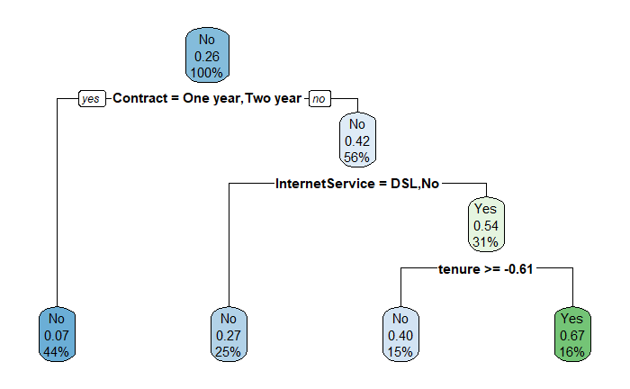

```r
rpart.plot(Tree)
```

```r
Forest <- randomForest(Churn~.,Trainchurn, ntree = 500, split = 'gini')
summary(Forest)
```

```
                Length Class  Mode
call               5   -none- call
type               1   -none- character
predicted       4570   factor numeric
err.rate        1500   -none- numeric
confusion          6   -none- numeric
votes           9140   matrix numeric
oob.times       4570   -none- numeric
classes            2   -none- character
importance        19   -none- numeric
importanceSD       0   -none- NULL
localImportance    0   -none- NULL
proximity          0   -none- NULL
ntree              1   -none- numeric
mtry               1   -none- numeric
forest            14   -none- list
y               4570   factor numeric
test               0   -none- NULL
inbag              0   -none- NULL
terms              3   terms  call
```

Now we will evaluate the random forest model.

```r
pred_Forest <- predict(Forest, Testchurn, type='class')

Forest_cm <- confusionMatrix(pred_Forest, Testchurn$Churn, mode = "everything")
Forest_cm
```

```
Confusion Matrix and Statistics

          Reference
Prediction   No  Yes
       No  1639  321
       Yes  165  337

               Accuracy : 0.8026
                 95% CI : (0.7863, 0.8182)
    No Information Rate : 0.7327
    P-Value [Acc > NIR] : 3.876e-16

                  Kappa : 0.455

 Mcnemar's Test P-Value : 2.051e-12

            Sensitivity : 0.9085
            Specificity : 0.5122
         Pos Pred Value : 0.8362
         Neg Pred Value : 0.6713
              Precision : 0.8362
                 Recall : 0.9085
                     F1 : 0.8709
             Prevalence : 0.7327
         Detection Rate : 0.6657
   Detection Prevalence : 0.7961
      Balanced Accuracy : 0.7103

       'Positive' Class : No
```

**3. Logistic Regression** Now we use the logistic regression model. We assume that there is some dependency of each attribute on the target feature.

```r
LogReg <- glm(Churn~., data = Trainchurn, family='binomial')
summary(LogReg)
```

```
Call:
glm(formula = Churn ~ ., family = "binomial", data = Trainchurn)

Deviance Residuals:
    Min       1Q   Median       3Q      Max
-1.7319  -0.6822  -0.2976   0.7670   3.3963

Coefficients: (7 not defined because of singularities)
                                      Estimate Std. Error z value Pr(>|z|)
(Intercept)                          -2.960337   1.559347  -1.898 0.057637 .
genderMale                            0.031876   0.079885   0.399 0.689880
SeniorCitizen1                        0.154417   0.103682   1.489 0.136400
PartnerYes                           -0.009181   0.096023  -0.096 0.923827
DependentsYes                        -0.074064   0.110050  -0.673 0.500948
tenure                               -1.455641   0.189153  -7.696 1.41e-14 ***
PhoneServiceYes                       0.348069   0.797093   0.437 0.662348
MultipleLinesNo phone service               NA         NA      NA       NA
MultipleLinesYes                      0.384926   0.217176   1.772 0.076326 .
InternetServiceFiber optic            2.047308   0.973742   2.103 0.035508 *
InternetServiceNo                    -2.171138   0.988577  -2.196 0.028076 *
OnlineSecurityNo internet service           NA         NA      NA       NA
OnlineSecurityYes                    -0.116531   0.217328  -0.536 0.591821
OnlineBackupNo internet service             NA         NA      NA       NA
OnlineBackupYes                       0.109673   0.214077   0.512 0.608437
DeviceProtectionNo internet service         NA         NA      NA       NA
DeviceProtectionYes                   0.183378   0.216027   0.849 0.395957
TechSupportNo internet service              NA         NA      NA       NA
TechSupportYes                       -0.145804   0.222861  -0.654 0.512959
StreamingTVNo internet service              NA         NA      NA       NA
StreamingTVYes                        0.612855   0.397774   1.541 0.123387
StreamingMoviesNo internet service          NA         NA      NA       NA
StreamingMoviesYes                    0.730781   0.400400   1.825 0.067982 .
ContractOne year                     -0.718115   0.134486  -5.340 9.31e-08 ***
ContractTwo year                     -1.285962   0.209838  -6.128 8.88e-10 ***
PaperlessBillingYes                   0.324300   0.092462   3.507 0.000453 ***
PaymentMethodCredit card (automatic) -0.149187   0.141143  -1.057 0.290513
PaymentMethodElectronic check         0.231245   0.115818   1.997 0.045866 *
PaymentMethodMailed check            -0.039320   0.142349  -0.276 0.782379
MonthlyCharges                       -1.516561   1.168413  -1.298 0.194299
TotalCharges                          0.770438   0.197837   3.894 9.85e-05 ***
---
Signif. codes:  0 ‘***’ 0.001 ‘**’ 0.01 ‘*’ 0.05 ‘.’ 0.1 ‘ ’ 1

(Dispersion parameter for binomial family taken to be 1)

    Null deviance: 5284.8  on 4569  degrees of freedom
Residual deviance: 3835.7  on 4546  degrees of freedom
AIC: 3883.7

Number of Fisher Scoring iterations: 6
```

Now we will evaluate the logistic regression model.

```r
pred_LogReg <- predict(LogReg, Testchurn, type = 'response')
summary(pred_LogReg)
```

```
    Min.  1st Qu.   Median     Mean  3rd Qu.     Max.
0.001251 0.046483 0.184774 0.263748 0.461278 0.816871
```

```r
LogReg_target <- ifelse(pred_LogReg > 0.45, 'Yes', 'No')

LogReg_cm <- confusionMatrix(as.factor(LogReg_target), Testchurn$Churn, mode = "everything")
LogReg_cm
```

```
Confusion Matrix and Statistics

          Reference
Prediction   No  Yes
       No  1579  244
       Yes  225  414

               Accuracy : 0.8095
                 95% CI : (0.7934, 0.8248)
    No Information Rate : 0.7327
    P-Value [Acc > NIR] : <2e-16

                  Kappa : 0.5091

 Mcnemar's Test P-Value : 0.4059

            Sensitivity : 0.8753
            Specificity : 0.6292
         Pos Pred Value : 0.8662
         Neg Pred Value : 0.6479
              Precision : 0.8662
                 Recall : 0.8753
                     F1 : 0.8707
             Prevalence : 0.7327
         Detection Rate : 0.6413
   Detection Prevalence : 0.7405
      Balanced Accuracy : 0.7522

       'Positive' Class : No
```